# Lung Condition Classification on COVID-19 Image Dataset

# 1. Introduction

This computer vision-based project is focused on model building towards multi-class classification in identifying whether a patient has one of three lung conditions:

1. Infected with COVID-19
2. Viral Pneumonia
3. Normal

Done with convolutional neural networks (CNN), the goal of the model is to provide a diagnosis based on a patient’s X-ray scan, with high-AUC and classification accuracy.

Hopefully, the model I created will benefit both medical staff as well as data enthusiasts like myself, as the challenge of interpreting X-ray scans are often steep without much domain expertise in pulmonology and/or virology. This is where the neural network comes in.

> **NOTE: Please do not test diagnostic performance of a model without an extensive clinical study!**

*At any rate, please consider this to be my modest form of contribution towards addressing the COVID-19 pandemic that's currently ravaging the world.*

## 1.1. Source & Acknowledgements

The dataset was uploaded to [Kaggle](https://www.kaggle.com/pranavraikokte/covid19-image-dataset) by the user [Pranav Raikote](https://www.kaggle.com/pranavraikokte) around April 2020, but only gained engagement in later months up until today (25 Feb 2021).

Original data is sourced from University of Montreal via their publicly accessible [GitHub repository](https://github.com/ieee8023/covid-chestxray-dataset).

## 1.2. Data License

This data is licensed under **Creative Commons Attribution-ShareAlike 4.0 International Public License (CC BY-SA 4.0)**

[figure not shown]

## 1.3. Framework Summary

The model will be built around `Keras`, specifically wrapped with stacked `Conv2D()` and `MaxPooling2D()` layers before eventually passing the flattened feature matrices onto `Dense()` layers for final classification.

# 2. Image Data Loading

First, we import the essential modules:

```python
import os, sys

import pandas as pd
import numpy as np
import tensorflow as tf
```

A brief preview of the images this project will be working around:

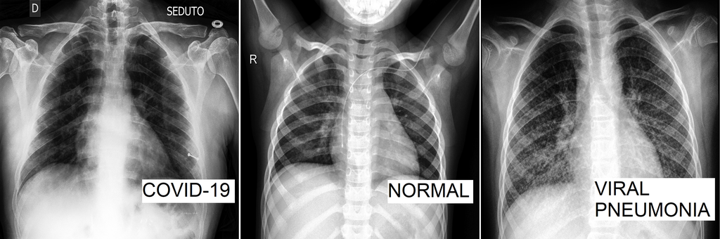

Load the images onto `tensorflow` before pre-processing. We split training set into 80% training and 20% validation.

```python
train_loader = tf.keras.preprocessing.image.ImageDataGenerator(
    rescale = (1.0 / 255), # Pixel normalization
    validation_split = 0.2, # Splits into 20% validation set
    zoom_range=0.2, # Augmentation parameter
    rotation_range=15, # Augmentation parameter
    width_shift_range=0.05, # Augmentation parameter
    height_shift_range=0.05) # Augmentation parameter

test_loader = tf.keras.preprocessing.image.ImageDataGenerator(rescale = (1.0 / 255))

print("For training set: ")
train_iterator = train_loader.flow_from_directory('data/train',
                                                     class_mode='categorical',
                                                     color_mode='grayscale',
                                                     target_size = (512, 512),
                                                     subset = "training",
                                                     # save_to_dir = 'data/debug' to manually check transformed images
                                                     batch_size=16)

print("\nFor validation set: ")
val_iterator = train_loader.flow_from_directory('data/train',
                                                     class_mode='categorical',
                                                     color_mode='grayscale',
                                                     target_size = (512, 512),
                                                     subset = "validation",
                                                     # save_to_dir = 'data/debug' to manually check transformed images
                                                     batch_size=16)
print("\nFor test set: ")
test_iterator = test_loader.flow_from_directory("data/test",
                                                class_mode='categorical',
                                                target_size = (512, 512),
                                                color_mode='grayscale', batch_size = 66)

x_test, y_test = test_iterator.next()
```

```
For training set:
Found 201 images belonging to 3 classes.

For validation set:
Found 50 images belonging to 3 classes.

For test set:
Found 66 images belonging to 3 classes.
```

```python
# Quick sanity check
print("Dimensions of one sample in the training set:")
print(train_iterator.next()[0].shape)

print("\nDimensions of one label in the training set:")
print(train_iterator.next()[1].shape)

print("\nCheck respective class labels:")
print(list(train_iterator.class_indices.items()))
```

```
Dimensions of one sample in the training set:
(16, 512, 512, 1)

Dimensions of one label in the training set:
(16, 3)

Check respective class labels:
[('Covid', 0), ('Normal', 1), ('Viral Pneumonia', 2)]
```

The tensors in the test set represents the light intensity (as channels) in the images. As x-ray scans are considered *grayscale* in nature, we only have one channel per image.

- As shown in the `print` statement below, the closer the number is to `1`, the closer it is to *white* (and vice versa).
- In the test label preview, this particular datapoint belongs to class `1`, indicating this x-ray scan belongs to a person without COVID-19 nor Viral Pneumonia.

```python
print("Preview of test set: {}".format(x_test[0][0][40:50])) # This represents the light intensity in the images.
print("Preview of test labels: {}".format(y_test[0])) # This represents the label.
```

```
Preview of test set: [[0.48235297]
 [0.48627454]
 [0.47058827]
 [0.48235297]
 [0.62352943]
 [0.62352943]
 [0.6431373 ]
 [0.6313726 ]
 [0.6313726 ]
 [0.6392157 ]]
Preview of test labels: [0. 1. 0.]
```

## 2.1. Tensor Shape Definition

For sample batch input:

- `16` is the number of images per batch;
- `512 x 512` is the dimensions of the images, rescaled, overriding previous aspect ratio;
- `1` is the number of channels; because this is grayscale, 1 represents only one channel, the light channel.

For sample label:

- `16` is the number of images per batch;
- `3` is the number of classes:
> - Class `0` refers to `Covid`
> - Class `1` refers to `Normal`
> - Class `2` refers to `Viral Pneumonia`

## 2.2. Model Building

Stacking `Conv2D()` and `MaxPooling2D()` layers simultaneously are the main idea behind this whole network. Also, with `strides` set to `1` on convolutional layers, the model prevents any loss of information at the cost of training time. The full structure of the model can be seen below:

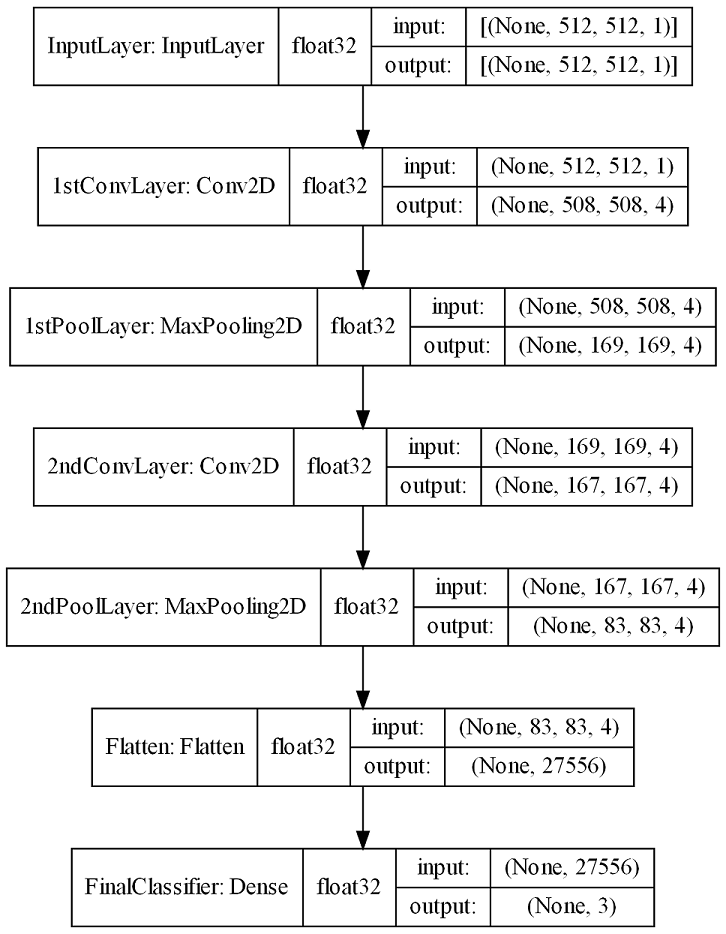

```python
model = tf.keras.Sequential(name = "LungClassifier")
model.add(tf.keras.Input(
    shape=(512, 512, 1), name = "InputLayer"))
model.add(tf.keras.layers.Conv2D(
    4, 5, strides=1, activation="relu", name = "1stConvLayer"))
model.add(tf.keras.layers.MaxPooling2D(
    pool_size=(3, 3), strides=(3, 3), name = "1stPoolLayer"))
model.add(tf.keras.layers.Conv2D(
    4, 3, strides=1, activation="relu", name = "2ndConvLayer"))
model.add(tf.keras.layers.MaxPooling2D(
    pool_size=(2,2), strides=(2,2), name = "2ndPoolLayer"))
model.add(tf.keras.layers.Flatten(name = "Flatten"))

## Wrap up the model building process before compiling

model.add(tf.keras.layers.Dense(3, activation="softmax", name = "FinalClassifier"))

(model.summary())
```

```
Model: "LungClassifier"
_________________________________________________________________
Layer (type)                 Output Shape              Param #
=================================================================
1stConvLayer (Conv2D)        (None, 508, 508, 4)       104
_________________________________________________________________
1stPoolLayer (MaxPooling2D)  (None, 169, 169, 4)       0
_________________________________________________________________
2ndConvLayer (Conv2D)        (None, 167, 167, 4)       148
_________________________________________________________________
2ndPoolLayer (MaxPooling2D)  (None, 83, 83, 4)         0
_________________________________________________________________
Flatten (Flatten)            (None, 27556)             0
_________________________________________________________________
FinalClassifier (Dense)      (None, 3)                 82671
=================================================================
Total params: 82,923
Trainable params: 82,923
Non-trainable params: 0
_________________________________________________________________
```

Even with this simple model, the network has a whopping amount of parameters to train with 82,923 total trainable weights. In this particular project, the input size is around `512 x 512` pixels which is a lot of tensors to compute per epoch. This is why I don't add any more deeper layers after the second pooling layer `2ndPoolLayer`, or even add another `Dense` before the final classifier `FinalClassifier`.

If I had done so, the model would possess an exponentially large number of weights to train, around 100-300 thousand.

## 2.3. Model Training

Some final configurations needed to be made before starting to fit our image tensors into the instantiated model:

- Define `EarlyStopping()` callback as a method to prevent overfitting towards the training dataset. Additional parameters:
  - Monitoring validation area under ROC curve, `val_auc`;
  - Letting the callback run for `10` more passes to see whether `val_auc` experiences a significant increase.

  However, this callback eventually was not used in the final model training and was only used to monitor performance before we iterate too much and yielded too little.
- Define `ModelCheckpoint()` callback for saving learned kernels/filters along the epochs. Additional parameters:
  - Monitoring validation multi-categorical accuracy, `val_categorical_accuracy`;
  - Saving only the model with most categorical accuracy along the epochs.
- Setting `Adam` as the network optimizer with learning rate configured to `0.005`.
- Setting categorical cross-entropy as the loss function.

```python
## Run this cell to start training
# Define earlystopping
es = tf.keras.callbacks.EarlyStopping(monitor='val_auc', mode='max', verbose=1, patience=10)

# Define model checkpoint
checkpoint = tf.keras.callbacks.ModelCheckpoint(
  "model_checkpoints", monitor="val_categorical_accuracy", verbose=1, save_best_only=True, mode="max")

model.compile(
    optimizer = tf.keras.optimizers.Adam(learning_rate=0.005), # Tweak learning rate as needed
    loss = tf.keras.losses.CategoricalCrossentropy(),
    metrics = [
      tf.keras.metrics.CategoricalAccuracy(),
      tf.keras.metrics.AUC()
      ]
)

model.fit(
        train_iterator,
        steps_per_epoch= train_iterator.samples/16, # Samples divided by batch size
        epochs = 40,
        validation_data = val_iterator,
        validation_steps = val_iterator.samples/16, # Samples divided by batch size
        callbacks = [checkpoint])
```

*Note: output of the training cell is collapsed to save space.*

## 2.4. Model Evaluation

With this simple model, the evaluation metrics for validation dataset comes out surprisingly good with:

- ~0.94 area under ROC curve (perfect AUC is 1)
- ~90% multi-categorical prediction accuracy (perfect accuracy is 100%)

As a side note, a baseline model would only possess 33.3% multi-categorical prediction accuracy.

After the model performance is deemed reasonable, we evaluate on the test set of total 60+ images, as well as calculate ground truth versus prediction labels with `sklearn`'s `classification_report`.

```python
cross_entropy, acc, auc = model.evaluate(x_test, y_test)
print("------------------ EVALUATION FINISHED! ------------------".center(115))
print("""Final Multi-Categorical Cross-Entropy (loss func.) is {}
Final Multi-Categorical Accuracy (eval. metric) is {}
Final Area Under ROC Curve (eval. metric) is {}""".format(cross_entropy, acc, auc))
```

```
                             ------------------ EVALUATION FINISHED! ------------------
Final Multi-Categorical Cross-Entropy (loss func.) is 0.4713405966758728
Final Multi-Categorical Accuracy (eval. metric) is 0.8484848737716675
Final Area Under ROC Curve (eval. metric) is 0.9465678930282593
```

Calculating precision, recall, and F1-score of the three classes. As we can see, this dataset is totally not biased as there are rougly the same amount of images in each class.

The most important result is the F1-score, which uses the harmonic mean of all predictions in all classes. F1-score represents the overall *viability* of the model.

```python
from sklearn.metrics import classification_report
y_estimate = model.predict(x_test)
y_estimate = np.argmax(y_estimate, axis = 1)
y_true = np.argmax(y_test, axis = 1)
print(classification_report(y_true, y_estimate))
```

```
              precision    recall  f1-score   support

           0       1.00      0.81      0.89        26
           1       0.71      1.00      0.83        20
           2       0.88      0.75      0.81        20

    accuracy                           0.85        66
   macro avg       0.87      0.85      0.85        66
weighted avg       0.88      0.85      0.85        66
```

# 3. Conclusion

## 3.1. Model Performance

With only a simple architecture, this CNN model reached the following metrics tested on unseen data:

- **84% classification accuracy**, this means the trained model predicts the correct class 84% of the time.
- **0.94 AUC of the ROC curve.**, this means for a random, unseen x-ray, there is a 94% chance the model would predict towards a true class than to a false one.

## 3.2. Recommendation

For future modelling, I would absolutely advise to normalize all the input tensors first (scaled to floats 0-1); as neural networks struggle with large integers in computing their weights/kernels. Doing this, whilst may seem trivial at first, can potentially increase evaluation metrics up to 10-20% on validation data set.

The pre-trained model had also been exported, in case anyone in the data science community would like to train it further with larger datasets.

```python
# Run this cell to export model

tf.keras.utils.plot_model(
    model,
    to_file="model.png",
    show_shapes=True,
    show_dtype=True,
    show_layer_names=True,
    rankdir="TB",
    expand_nested=True,
    dpi=216,
)
```

*--- Written, tested, and published by Charis Chrisna ---*  
[(Portfolio)](http://notpestilence.github.io)